# **Cell 1: Setup & Load Dataset**

### **Purpose**

This cell is the **entry point** of the entire notebook. It installs and imports all the external libraries needed, then downloads and loads the Cirrhosis Prediction Dataset from Kaggle into a raw DataFrame (`df_raw`) that will be used throughout the notebook.

### **Line-by-Line Explanation**

| Line | What it does |
| --- | --- |
| `!pip install kagglehub -q` | Installs the `kagglehub` package — a Kaggle API wrapper that allows datasets to be downloaded directly inside Google Colab without manually uploading files. The `-q` flag suppresses verbose output. |
| `import kagglehub` | Imports the Kaggle Hub library for dataset downloading. |
| `import os` | Imports Python's built-in OS module, used later to construct file paths with `os.path.join()`. |
| `import pandas as pd` | Imports the Pandas library for DataFrame operations — loading, cleaning, and transforming tabular data. |
| `import numpy as np` | Imports NumPy for numerical operations such as array manipulation, statistical calculations, and NaN handling. |
| `import matplotlib.pyplot as plt` | Imports Matplotlib for creating static charts and visualizations. |
| `import seaborn as sns` | Imports Seaborn, a higher-level visualization library built on Matplotlib (available for potential use in EDA). |
| `from sklearn.linear_model import LogisticRegression` | Imports the Logistic Regression model class from scikit-learn. This is the core predictive model used throughout the exercise. |
| `from sklearn.model_selection import train_test_split` | Imports the function for splitting data into training and testing sets (80/20 split used later). |
| `from sklearn.preprocessing import StandardScaler` | Imports the StandardScaler for feature normalization — ensures all features are on the same scale before training. |
| `from sklearn.metrics import (accuracy_score, precision_score, recall_score, f1_score, confusion_matrix, ConfusionMatrixDisplay)` | Imports all performance evaluation tools used in the three experiments. |
| `path = kagglehub.dataset_download(...)` | Downloads the cirrhosis dataset from Kaggle and stores the local file path. The dataset is only downloaded once per session; subsequent calls reuse the cached version. |
| `df_raw = pd.read_csv(os.path.join(path, "cirrhosis.csv"))` | Reads the CSV file at the downloaded path into a Pandas DataFrame named `df_raw`. This is the **original unmodified dataset** preserved as a reference. |
| `print(df_raw.shape[0], df_raw.shape[1])` | Prints the number of rows and columns to confirm the dataset loaded correctly. |
| `df_raw.head()` | Displays the first 5 rows of the raw DataFrame for a quick inspection of structure and values. |

### **Input**

- No prior data — this is the first cell.
- Requires an active internet connection to download from Kaggle.

### **Output**

- `df_raw` — a Pandas DataFrame containing the **raw, unmodified** Cirrhosis dataset (418 rows × 20 columns).
- Console confirmation: dataset shape and first 5 rows.

```python
# ============================================================
# CELL 1: SETUP & LOAD DATASET
# ============================================================

!pip install kagglehub -q

import kagglehub
import os
import pandas as pd
import numpy as np
import matplotlib.pyplot as plt
import seaborn as sns
from sklearn.linear_model import LogisticRegression
from sklearn.model_selection import train_test_split
from sklearn.preprocessing import StandardScaler
from sklearn.metrics import (accuracy_score, precision_score,
                             recall_score, f1_score,
                             confusion_matrix, ConfusionMatrixDisplay)

# Download dataset (only downloads once per session)
path = kagglehub.dataset_download("fedesoriano/cirrhosis-prediction-dataset")
df_raw = pd.read_csv(os.path.join(path, "cirrhosis.csv"))

print("=" * 55)
print("  ✅ Dataset loaded successfully")
print(f"  Shape: {df_raw.shape[0]} rows × {df_raw.shape[1]} columns")
print("=" * 55)
df_raw.head()
```

```
Downloading to /root/.cache/kagglehub/datasets/fedesoriano/cirrhosis-prediction-dataset/2.archive...
```

```
Extracting files...
=======================================================
  ✅ Dataset loaded successfully
  Shape: 418 rows × 20 columns
=======================================================
```

|  | ID | N_Days | Status | Drug | Age | Sex | Ascites | Hepatomegaly | Spiders | Edema | Bilirubin | Cholesterol | Albumin | Copper | Alk_Phos | SGOT | Tryglicerides | Platelets | Prothrombin | Stage |
| --- | --- | --- | --- | --- | --- | --- | --- | --- | --- | --- | --- | --- | --- | --- | --- | --- | --- | --- | --- | --- |
| 0 | 1 | 400 | D | D-penicillamine | 21464 | F | Y | Y | Y | Y | 14.5 | 261.0 | 2.60 | 156.0 | 1718.0 | 137.95 | 172.0 | 190.0 | 12.2 | 4.0 |
| 1 | 2 | 4500 | C | D-penicillamine | 20617 | F | N | Y | Y | N | 1.1 | 302.0 | 4.14 | 54.0 | 7394.8 | 113.52 | 88.0 | 221.0 | 10.6 | 3.0 |
| 2 | 3 | 1012 | D | D-penicillamine | 25594 | M | N | N | N | S | 1.4 | 176.0 | 3.48 | 210.0 | 516.0 | 96.10 | 55.0 | 151.0 | 12.0 | 4.0 |
| 3 | 4 | 1925 | D | D-penicillamine | 19994 | F | N | Y | Y | S | 1.8 | 244.0 | 2.54 | 64.0 | 6121.8 | 60.63 | 92.0 | 183.0 | 10.3 | 4.0 |
| 4 | 5 | 1504 | CL | Placebo | 13918 | F | N | Y | Y | N | 3.4 | 279.0 | 3.53 | 143.0 | 671.0 | 113.15 | 72.0 | 136.0 | 10.9 | 3.0 |

# **Cell 2: Data Quality Assessment**

### **Purpose**

Before cleaning or modifying anything, this cell performs a **visual inspection of the raw data's quality** across three dimensions:

1. **Missing values** — which columns have them and how many
2. **Class imbalance** — how the target variable `Status` is distributed
3. **Outliers** — which numeric features contain extreme values

This directly follows the guidance from **Lecture 6 (Poor-Quality Data)**: *"It is often well worth the effort to spend time cleaning up your training data."* This cell produces the evidence that justifies the cleaning decisions made in Cell 3.

### **Line-by-Line Explanation**

| Line | What it does |
| --- | --- |
| `df_check = df_raw.copy()` | Creates a working copy of the raw data. This ensures `df_raw` is never modified during inspection. |
| `df_check.replace("NA", np.nan, inplace=True)` | The dataset stores missing values as the **string "NA"** instead of Python's `NaN`. This converts them so Pandas can detect and count them with `.isnull()`. |
| `df_check['Stage'] = pd.to_numeric(df_check['Stage'], errors='coerce')` | `Stage` was stored as a string/object type. This converts it to numeric; non-numeric entries become `NaN`. |
| `fig, axes = plt.subplots(1, 3, figsize=(18, 6))` | Creates a single figure with 3 side-by-side subplots for the three quality checks. |
| `fig.patch.set_facecolor('#0f1117')` | Sets the overall figure background to a dark color for a professional dark-theme look. |
| **--- Plot 1: Missing Values ---** |  |
| `missing = df_check.isnull().sum()` | Counts the number of `NaN` values per column. |
| `missing = missing[missing > 0].sort_values(ascending=False)` | Filters to only show columns that actually have missing values, sorted from most to least. |
| `missing_pct = missing / len(df_check) * 100` | Converts raw counts to percentages for more meaningful comparison. |
| `colors = ['#ff4444' if p > 25 else '#ffa500' for p in missing_pct]` | Color-codes bars: red for columns missing more than 25% of values, orange for less severe missingness. |
| `ax1.barh(...)` | Creates a horizontal bar chart of missing percentages per column. |
| **--- Plot 2: Class Imbalance ---** |  |
| `status_counts = df_check['Status'].value_counts()` | Counts how many samples belong to each class: C (Alive), D (Died), CL (Liver Transplant). |
| `ax2.bar(...)` | Creates a vertical bar chart showing the class distribution of the target variable. |
| **--- Plot 3: Outliers ---** |  |
| `outlier_cols = ['Bilirubin', 'Cholesterol', 'Copper', 'Alk_Phos', 'SGOT']` | Selects clinical lab features known to have extreme values in liver disease patients. |
| `ax3.boxplot(plot_data, patch_artist=True, ...)` | Creates a boxplot for each selected feature. The whiskers show the IQR range; points beyond the whiskers are potential outliers. |
| `plt.savefig('data_quality.png', ...)` | Saves the entire 3-panel figure as a PNG image for reference and reporting. |

### **Input**

- `df_raw` — the original raw dataset from Cell 1.

### **Output**

- `df_check` — a temporary inspection copy (not used beyond this cell).
- A 3-panel visualization saved as `data_quality.png` showing:
  - Which columns have missing values and how severe they are
  - How balanced the target classes are
  - Which features contain extreme outlier values
- This output directly informs the cleaning strategy in Cell 3.

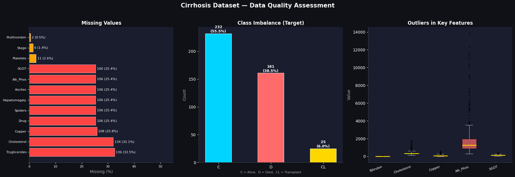

```python
# ============================================================
# CELL 2: DATA QUALITY ASSESSMENT
# ============================================================

# Work on a copy so raw data stays untouched
df_check = df_raw.copy()
df_check.replace("NA", np.nan, inplace=True)
df_check['Stage'] = pd.to_numeric(df_check['Stage'], errors='coerce')

fig, axes = plt.subplots(1, 3, figsize=(18, 6))
fig.patch.set_facecolor('#0f1117')
fig.suptitle('Cirrhosis Dataset — Data Quality Assessment',
             color='white', fontsize=15, fontweight='bold', y=1.02)

# ── 1. Missing Values per Column ────────────────────────────
ax1 = axes[0]
ax1.set_facecolor('#1a1d2e')
missing = df_check.isnull().sum()
missing = missing[missing > 0].sort_values(ascending=False)
missing_pct = missing / len(df_check) * 100
colors = ['#ff4444' if p > 25 else '#ffa500' for p in missing_pct]
bars = ax1.barh(missing.index, missing_pct.values,
                color=colors, edgecolor='white', linewidth=0.5)
for bar, val, raw in zip(bars, missing_pct.values, missing.values):
    ax1.text(bar.get_width() + 0.5, bar.get_y() + bar.get_height()/2,
             f'{raw} ({val:.1f}%)', va='center', color='white', fontsize=8)
ax1.set_title('Missing Values', color='white', fontweight='bold', fontsize=12)
ax1.set_xlabel('Missing (%)', color='#aaaaaa')
ax1.tick_params(colors='white', labelsize=8)
ax1.spines[['top','right']].set_visible(False)
ax1.spines[['left','bottom']].set_color('#444444')
ax1.set_xlim(0, 55)

# ── 2. Target Class Imbalance ────────────────────────────────
ax2 = axes[1]
ax2.set_facecolor('#1a1d2e')
status_counts = df_check['Status'].value_counts()
bar_colors = ['#00d4ff', '#ff6b6b', '#ffd700']
bars2 = ax2.bar(status_counts.index, status_counts.values,
                color=bar_colors, edgecolor='white', linewidth=0.7, width=0.5)
for bar, val in zip(bars2, status_counts.values):
    ax2.text(bar.get_x() + bar.get_width()/2, bar.get_height() + 2,
             f'{val}\n({val/len(df_check)*100:.1f}%)',
             ha='center', color='white', fontsize=9, fontweight='bold')
ax2.set_title('Class Imbalance (Target)', color='white', fontweight='bold', fontsize=12)
ax2.set_xlabel('C = Alive,  D = Died,  CL = Transplant', color='#aaaaaa', fontsize=8)
ax2.set_ylabel('Count', color='#aaaaaa')
ax2.tick_params(colors='white')
ax2.spines[['top','right']].set_visible(False)
ax2.spines[['left','bottom']].set_color('#444444')

# ── 3. Outliers via Boxplot ──────────────────────────────────
ax3 = axes[2]
ax3.set_facecolor('#1a1d2e')
outlier_cols = ['Bilirubin', 'Cholesterol', 'Copper', 'Alk_Phos', 'SGOT']
plot_data = [df_check[c].dropna().values for c in outlier_cols]
bp = ax3.boxplot(plot_data, patch_artist=True,
                 medianprops=dict(color='#ffd700', linewidth=2),
                 whiskerprops=dict(color='#aaaaaa'),
                 capprops=dict(color='#aaaaaa'),
                 flierprops=dict(marker='o', color='#ff6b6b',
                                 markersize=3, alpha=0.6))
box_colors = ['#00d4ff','#4ecdc4','#ffd700','#ff6b6b','#a29bfe']
for patch, color in zip(bp['boxes'], box_colors):
    patch.set_facecolor(color)
    patch.set_alpha(0.7)
ax3.set_xticks(range(1, len(outlier_cols)+1))
ax3.set_xticklabels(outlier_cols, rotation=20, ha='right',
                    color='white', fontsize=8)
ax3.tick_params(axis='y', colors='white')
ax3.set_title('Outliers in Key Features', color='white', fontweight='bold', fontsize=12)
ax3.set_ylabel('Value', color='#aaaaaa')
ax3.spines[['top','right']].set_visible(False)
ax3.spines[['left','bottom']].set_color('#444444')

plt.tight_layout()
plt.savefig('data_quality.png', dpi=150, bbox_inches='tight', facecolor='#0f1117')
plt.show()
```

# **Cell 3: Data Cleaning**

### **Purpose**

This cell transforms the raw, messy dataset into a **clean, fully numeric, model-ready DataFrame** (`df`). Every step directly addresses one of the data quality issues identified in Cell 2. This follows **Lecture 6's guidance on Poor-Quality Data**: handling missing values, removing duplicates, encoding categorical variables, and making justified decisions about outliers.

### **Line-by-Line Explanation**

[output not shown]

### **Input**

- `df_raw` — the original unmodified dataset from Cell 1.

### **Output**

```
=======================================================
  ORIGINAL:  418 rows x 20 columns
=======================================================

[OK] Step 1: String 'NA' converted to NaN
     Total missing cells: 1033

[OK] Step 2: Dropped 'ID' (not a predictor)

[OK] Step 3: Duplicates removed
     418 -> 418 rows (none found)

[OK] Step 4: 'Status' encoded -> Died=1, Survived=0
     Died (1): 161 | Survived (0): 257

[OK] Step 5a: 'Drug' — 106 missing -> mode 'D-penicillamine'

[OK] Step 5a: 'Ascites' — 106 missing -> mode 'N'

[OK] Step 5a: 'Hepatomegaly' — 106 missing -> mode 'Y'

[OK] Step 5a: 'Spiders' — 106 missing -> mode 'N'

[OK] Step 5b: 'Cholesterol' — 134 missing -> median 309.50

[OK] Step 5b: 'Copper' — 108 missing -> median 73.00

[OK] Step 5b: 'Alk_Phos' — 106 missing -> median 1259.00

[OK] Step 5b: 'SGOT' — 106 missing -> median 114.70

[OK] Step 5b: 'Tryglicerides' — 136 missing -> median 108.00

[OK] Step 5b: 'Platelets' — 11 missing -> median 251.00

[OK] Step 5b: 'Prothrombin' — 2 missing -> median 10.60

[OK] Step 5c: 'Stage' — 6 missing -> mode 3.0

[OK] Step 6: Categorical columns encoded

[OK] Step 7: 'Age' converted from days -> years

[!] Step 8: Outlier Assessment
     'Bilirubin': 46 potential outliers identified — retained (genuine clinical values)
     'Cholesterol': 51 potential outliers identified — retained (genuine clinical values)
     'Copper': 45 potential outliers identified — retained (genuine clinical values)
     'Alk_Phos': 45 potential outliers identified — retained (genuine clinical values)
     'SGOT': 26 potential outliers identified — retained (genuine clinical values)
     'Tryglicerides': 47 potential outliers identified — retained (genuine clinical values)

     All rows retained — no outliers removed

=======================================================
  CLEANING COMPLETE
=======================================================
  Final shape   : 418 rows x 19 columns
  Missing values: 0
  Target balance: Died = 161 | Survived = 257
=======================================================
```

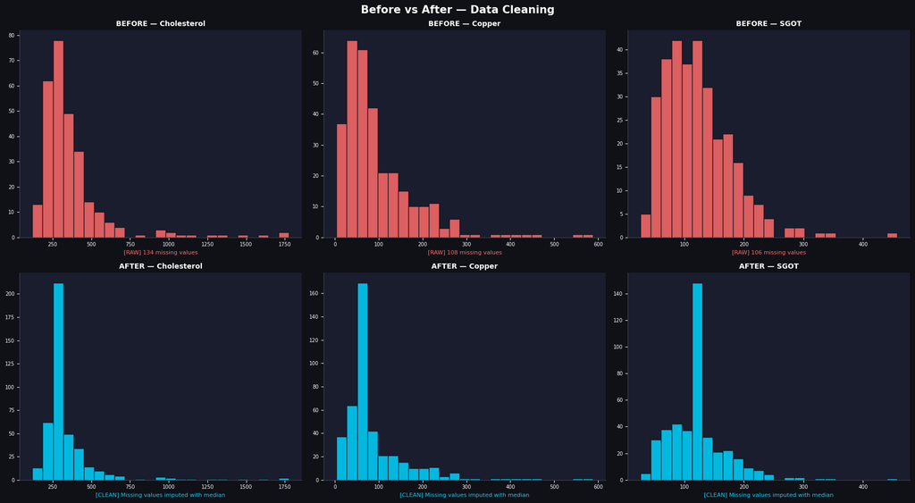

```python
# ============================================================
# CELL 3: DATA CLEANING
# ============================================================

# Start from the raw copy — never modify df_raw directly
df = df_raw.copy()

print("=" * 55)
print(f"  ORIGINAL:  {df.shape[0]} rows x {df.shape[1]} columns")
print("=" * 55)

# ── Step 1: Fix string "NA" → actual NaN ─────────────────────
df.replace("NA", np.nan, inplace=True)
df['Stage'] = pd.to_numeric(df['Stage'], errors='coerce')
print(f"\n[OK] Step 1: String 'NA' converted to NaN")
print(f"     Total missing cells: {df.isnull().sum().sum()}")

# ── Step 2: Drop ID column ───────────────────────────────────
df.drop(columns=['ID'], inplace=True)
print(f"\n[OK] Step 2: Dropped 'ID' (not a predictor)")

# ── Step 3: Remove duplicates ────────────────────────────────
before = len(df)
df.drop_duplicates(inplace=True)
print(f"\n[OK] Step 3: Duplicates removed")
print(f"     {before} -> {len(df)} rows "
      f"({'none found' if before == len(df) else f'{before - len(df)} removed'})")

# ── Step 4: Encode binary target ─────────────────────────────
df['Status'] = (df['Status'] == 'D').astype(int)
print(f"\n[OK] Step 4: 'Status' encoded -> Died=1, Survived=0")
print(f"     Died (1): {df['Status'].sum()} | "
      f"Survived (0): {(df['Status'] == 0).sum()}")

# ── Step 5a: Fill categorical missing → Mode ─────────────────
cat_fill = ['Drug', 'Ascites', 'Hepatomegaly', 'Spiders']
for col in cat_fill:
    mode_val = df[col].mode()[0]
    n = df[col].isnull().sum()
    df[col] = df[col].fillna(mode_val)
    print(f"\n[OK] Step 5a: '{col}' — {n} missing -> mode '{mode_val}'")

# ── Step 5b: Fill numeric missing → Median ───────────────────
num_fill = ['Cholesterol', 'Copper', 'Alk_Phos',
            'SGOT', 'Tryglicerides', 'Platelets', 'Prothrombin']
for col in num_fill:
    median_val = df[col].median()
    n = df[col].isnull().sum()
    df[col] = df[col].fillna(median_val)
    print(f"\n[OK] Step 5b: '{col}' — {n} missing -> median {median_val:.2f}")

# ── Step 5c: Fill Stage → Mode ───────────────────────────────
n = df['Stage'].isnull().sum()
stage_mode = df['Stage'].mode()[0]
df['Stage'] = df['Stage'].fillna(stage_mode)
print(f"\n[OK] Step 5c: 'Stage' — {n} missing -> mode {stage_mode}")

# ── Step 6: Encode categorical columns ───────────────────────
df['Sex']  = (df['Sex']  == 'M').astype(int)
df['Drug'] = (df['Drug'] == 'D-penicillamine').astype(int)
for col in ['Ascites', 'Hepatomegaly', 'Spiders']:
    df[col] = (df[col] == 'Y').astype(int)
df['Edema'] = df['Edema'].map({'N': 0, 'S': 0.5, 'Y': 1})
print(f"\n[OK] Step 6: Categorical columns encoded")

# ── Step 7: Convert Age days → years ─────────────────────────
df['Age'] = (df['Age'] / 365.25).round(1)
print(f"\n[OK] Step 7: 'Age' converted from days -> years")

# ── Step 8: Outlier Assessment ───────────────────────────────
print(f"\n[!] Step 8: Outlier Assessment")
for col in ['Bilirubin', 'Cholesterol', 'Copper',
            'Alk_Phos', 'SGOT', 'Tryglicerides']:
    Q1, Q3 = df[col].quantile(0.25), df[col].quantile(0.75)
    IQR    = Q3 - Q1
    n_out  = ((df[col] < Q1 - 1.5 * IQR) |
               (df[col] > Q3 + 1.5 * IQR)).sum()
    print(f"     '{col}': {n_out} potential outliers "
          f"identified — retained (genuine clinical values)")
print(f"\n     All rows retained — no outliers removed")

# ── Final Summary ─────────────────────────────────────────────
print("\n" + "=" * 55)
print("  CLEANING COMPLETE")
print("=" * 55)
print(f"  Final shape   : {df.shape[0]} rows x {df.shape[1]} columns")
print(f"  Missing values: {df.isnull().sum().sum()}")
print(f"  Target balance: Died = {df['Status'].sum()} | "
      f"Survived = {(df['Status']==0).sum()}")
print("=" * 55)

# ── Before vs After Visualization ────────────────────────────
df_check2 = df_raw.copy()
df_check2.replace("NA", np.nan, inplace=True)

fig, axes = plt.subplots(2, 3, figsize=(18, 10))
fig.patch.set_facecolor('#0f1117')
fig.suptitle('Before vs After — Data Cleaning',
             color='white', fontsize=15, fontweight='bold')

plot_cols = ['Cholesterol', 'Copper', 'SGOT']
for i, col in enumerate(plot_cols):
    for row, (data, label, color, note) in enumerate([
        (df_check2[col].dropna(), 'BEFORE', '#ff6b6b',
         f'[RAW] {df_check2[col].isnull().sum()} missing values'),
        (df[col], 'AFTER', '#00d4ff',
         '[CLEAN] Missing values imputed with median')
    ]):
        ax = axes[row][i]
        ax.set_facecolor('#1a1d2e')
        ax.hist(data, bins=25, color=color,
                edgecolor='#0f1117', alpha=0.85)
        ax.set_title(f'{label} — {col}', color='white',
                     fontweight='bold', fontsize=10)
        ax.tick_params(colors='white', labelsize=7)
        ax.spines[['top', 'right']].set_visible(False)
        ax.spines[['left', 'bottom']].set_color('#444444')
        ax.set_xlabel(note, color=color, fontsize=8)

plt.tight_layout()
plt.savefig('cleaning_summary.png', dpi=150,
            bbox_inches='tight', facecolor='#0f1117')
plt.show()
```

# **Cell 4: Model Building — Binary Logistic Regression (Baseline)**

### **Purpose**

This cell establishes the **global train/test split** that is reused across all three experiments (Cells 5, 6, 7), trains the **baseline Binary Logistic Regression model** using all 18 features with the default `C=1.0` hyperparameter, and produces the initial performance metrics and visualizations that serve as the benchmark for comparison.

This directly implements the **Logistic Regression model** from Lecture 5: the sigmoid function maps the linear combination of input features to a probability between 0 and 1, and the decision threshold of 0.5 determines the predicted class.

### **Line-by-Line Explanation**

| Line | What it does |
| --- | --- |
| `X = df.drop(columns=['Status'])` | Creates the **feature matrix** — all columns except the target variable. Contains 18 predictor columns. |
| `y = df['Status']` | Creates the **target vector** — the binary `Status` column (0=Survived, 1=Died). |
| `train_test_split(X, y, test_size=0.2, random_state=42, stratify=y)` | Splits data into 80% training (334 rows) and 20% testing (84 rows). `stratify=y` ensures the same proportion of Died/Survived is preserved in both sets. `random_state=42` ensures reproducibility. |
| `scaler_base = StandardScaler()` | Creates a StandardScaler instance that transforms features to have mean=0 and standard deviation=1. |
| `X_train_sc = scaler_base.fit_transform(X_train)` | **Fits** the scaler on training data and transforms it. The scaler learns the mean and std from training data only — this prevents data leakage. |
| `X_test_sc = scaler_base.transform(X_test)` | Applies the **same** scaling parameters (learned from training) to the test set. Never fit on test data. |
| `model = LogisticRegression(C=1.0, max_iter=1000, random_state=42)` | Creates the logistic regression model. `C=1.0` is the default regularization strength (baseline). `max_iter=1000` allows enough iterations for convergence on this dataset. |
| `model.fit(X_train_sc, y_train)` | **Trains** the model by finding the optimal sigmoid curve coefficients that minimize log loss on the training set. |
| `y_pred = model.predict(X_test_sc)` | Generates predictions on the **test set** using the default threshold of 0.5 (P ≥ 0.5 → Died=1). |
| `accuracy_score(y_test, y_pred)` | Computes the percentage of correct predictions overall. |
| `precision_score(y_test, y_pred)` | Of all patients predicted as Died, what fraction actually died. |
| `recall_score(y_test, y_pred)` | Of all patients who actually died, what fraction the model correctly identified. |
| `f1_score(y_test, y_pred)` | Harmonic mean of precision and recall — the primary metric for imbalanced datasets (per Lecture 6). |
| Confusion Matrix plot | Visualizes the 4 prediction outcomes: True Positives, True Negatives, False Positives, False Negatives. |
| Metrics Bar Chart | Visualizes all 4 metrics side-by-side as a bar chart for quick comparison. |

### **Why Stratified Split?**

The dataset has class imbalance (~38% Died, ~62% Survived). Without `stratify=y`, a random split might accidentally put most Died cases in one set, giving misleading performance results.

### **Why Scale Features?**

Logistic Regression uses gradient descent — if features have very different scales (e.g., Bilirubin ranges 0.3–28 vs. Age ranges 26–78), the algorithm converges poorly. StandardScaler normalizes all features to the same scale.

### **Input**

- `df` — the cleaned dataset from Cell 3.

### **Output**

- `X_train`, `X_test`, `y_train`, `y_test` — the **global train/test split** reused in all experiments.
- `X_train_sc`, `X_test_sc` — scaled feature matrices.
- `model` — the trained baseline logistic regression model.
- `y_pred` — predictions on the test set.
- Baseline performance metrics: Accuracy, Precision, Recall, F1-Score.
- Two visualizations: Confusion Matrix and Metrics Bar Chart, saved as `model_results.png`.

```
=======================================================
  GLOBAL TRAIN/TEST SPLIT (reused in all experiments)
=======================================================
  Training set : 334 rows | 18 features
  Testing set  : 84 rows | 18 features
  Train class  : Survived=205 | Died=129
  Test class   : Survived=52 | Died=32
=======================================================

CLEANED DATASET INFO:
<class 'pandas.core.frame.DataFrame'>
RangeIndex: 418 entries, 0 to 417
Data columns (total 19 columns):
 #   Column         Non-Null Count  Dtype
---  ------         --------------  -----
 0   N_Days         418 non-null    int64
 1   Status         418 non-null    int64
 2   Drug           418 non-null    int64
 3   Age            418 non-null    float64
 4   Sex            418 non-null    int64
 5   Ascites        418 non-null    int64
 6   Hepatomegaly   418 non-null    int64
 7   Spiders        418 non-null    int64
 8   Edema          418 non-null    float64
 9   Bilirubin      418 non-null    float64
 10  Cholesterol    418 non-null    float64
 11  Albumin        418 non-null    float64
 12  Copper         418 non-null    float64
 13  Alk_Phos       418 non-null    float64
 14  SGOT           418 non-null    float64
 15  Tryglicerides  418 non-null    float64
 16  Platelets      418 non-null    float64
 17  Prothrombin    418 non-null    float64
 18  Stage          418 non-null    float64
dtypes: float64(12), int64(7)
memory usage: 62.2 KB
None

CLEANED DATASET STATISTICS:
        N_Days  Status    Drug     Age     Sex  Ascites  Hepatomegaly  \
```

[output cut: 19 more lines]

```
         SGOT  Tryglicerides  Platelets  Prothrombin   Stage
count  418.00         418.00     418.00       418.00  418.00
mean   120.56         119.27     256.87        10.73    3.02
std     49.09          54.05      97.02         1.02    0.88
min     26.35          33.00      62.00         9.00    1.00
25%     91.00          95.00     190.00        10.00    2.00
50%    114.70         108.00     251.00        10.60    3.00
75%    135.75         127.75     315.50        11.10    4.00
max    457.25         598.00     721.00        18.00    4.00

[OK] BASELINE MODEL RESULTS (C=1.0, all 18 features)
  Accuracy  : 0.8571
  Precision : 0.8846
  Recall    : 0.7188
  F1-Score  : 0.7931
```

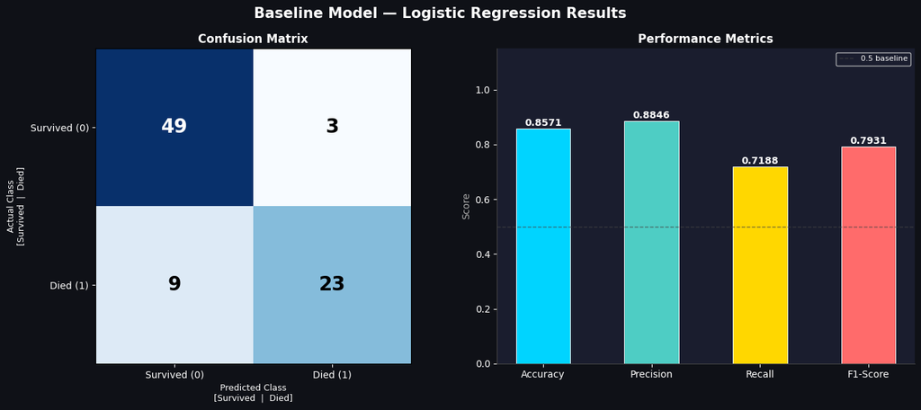

```python
# ============================================================
# CELL 4: MODEL BUILDING — Binary Logistic Regression
# ============================================================

# ── ONE Global Train/Test Split (80/20) ──────────────────────
X = df.drop(columns=['Status'])
y = df['Status']

X_train, X_test, y_train, y_test = train_test_split(
    X, y, test_size=0.2, random_state=42, stratify=y)

print("=" * 55)
print("  GLOBAL TRAIN/TEST SPLIT (reused in all experiments)")
print("=" * 55)
print(f"  Training set : {X_train.shape[0]} rows | "
      f"{X_train.shape[1]} features")
print(f"  Testing set  : {X_test.shape[0]} rows | "
      f"{X_test.shape[1]} features")
print(f"  Train class  : Survived={np.bincount(y_train)[0]} | "
      f"Died={np.bincount(y_train)[1]}")
print(f"  Test class   : Survived={np.bincount(y_test)[0]} | "
      f"Died={np.bincount(y_test)[1]}")
print("=" * 55)

print("\nCLEANED DATASET INFO:")
print(df.info())
print("\nCLEANED DATASET STATISTICS:")
print(df.describe().round(2))

# ── Feature Scaling ──────────────────────────────────────────
scaler_base = StandardScaler()
X_train_sc  = scaler_base.fit_transform(X_train)
X_test_sc   = scaler_base.transform(X_test)

# ── Baseline Model (C=1.0) ───────────────────────────────────
model = LogisticRegression(C=1.0, max_iter=1000, random_state=42)
model.fit(X_train_sc, y_train)
y_pred = model.predict(X_test_sc)

# ── Performance Metrics ──────────────────────────────────────
acc  = accuracy_score(y_test, y_pred)
prec = precision_score(y_test, y_pred)
rec  = recall_score(y_test, y_pred)
f1   = f1_score(y_test, y_pred)

print("\n[OK] BASELINE MODEL RESULTS (C=1.0, all 18 features)")
print(f"  Accuracy  : {acc:.4f}")
print(f"  Precision : {prec:.4f}")
print(f"  Recall    : {rec:.4f}")
print(f"  F1-Score  : {f1:.4f}")

# ── Visualization ─────────────────────────────────────────────
fig, axes = plt.subplots(1, 2, figsize=(14, 6))
fig.patch.set_facecolor('#0f1117')
fig.suptitle('Baseline Model — Logistic Regression Results',
             color='white', fontsize=15, fontweight='bold')

# ── Confusion Matrix ──────────────────────────────────────────
ax1 = axes[0]
ax1.set_facecolor('#1a1d2e')
cm   = confusion_matrix(y_test, y_pred)
disp = ConfusionMatrixDisplay(
    confusion_matrix=cm,
    display_labels=['Survived (0)', 'Died (1)'])
disp.plot(ax=ax1, colorbar=False, cmap='Blues')
ax1.set_title('Confusion Matrix', color='white',
              fontweight='bold', fontsize=12)
ax1.set_xlabel('Predicted Class\n[Survived  |  Died]',
               color='white', fontsize=9)
ax1.set_ylabel('Actual Class\n[Survived  |  Died]',
               color='white', fontsize=9)
ax1.tick_params(colors='white')

thresh_cm = cm.max() / 2
for text in ax1.texts:
    val = float(text.get_text())
    text.set_color('white' if val > thresh_cm else 'black')
    text.set_fontsize(20)
    text.set_fontweight('bold')
ax1.set_facecolor('#1a1d2e')

# ── Metrics Bar Chart ─────────────────────────────────────────
ax2 = axes[1]
ax2.set_facecolor('#1a1d2e')
metrics = ['Accuracy', 'Precision', 'Recall', 'F1-Score']
values  = [acc, prec, rec, f1]
colors  = ['#00d4ff', '#4ecdc4', '#ffd700', '#ff6b6b']
bars = ax2.bar(metrics, values, color=colors,
               edgecolor='white', linewidth=0.7, width=0.5)
for bar, val in zip(bars, values):
    ax2.text(bar.get_x() + bar.get_width()/2,
             bar.get_height() + 0.01,
             f'{val:.4f}', ha='center', color='white',
             fontsize=10, fontweight='bold')
ax2.set_ylim(0, 1.15)
ax2.set_title('Performance Metrics', color='white',
              fontweight='bold', fontsize=12)
ax2.tick_params(colors='white')
ax2.spines[['top','right']].set_visible(False)
ax2.spines[['left','bottom']].set_color('#444444')
ax2.set_ylabel('Score', color='#aaaaaa')
ax2.axhline(y=0.5, color='#444444', linestyle='--',
            linewidth=1, alpha=0.7, label='0.5 baseline')
ax2.legend(facecolor='#1a1d2e', labelcolor='white', fontsize=8)

plt.tight_layout()
plt.savefig('model_results.png', dpi=150,
            bbox_inches='tight', facecolor='#0f1117')
plt.show()
```

# **Cell 5: Experiment 1 — Hyperparameter Tuning (C Parameter)**

### **Purpose**

This experiment investigates how the **regularization parameter `C`** affects the logistic regression model's decision boundary shape, sigmoid curve steepness, and prediction performance. It follows the structure from **Lecture 5's Model Implementation** section, using `plot_class_regions_for_classifier_subplot` to visualize the decision boundaries.

**What is C?**

- `C` controls the inverse of regularization strength.
- **Small C (e.g., 0.001)** → strong regularization → model coefficients are penalized heavily → sigmoid curve flattens → model tends to underfit.
- **Large C (e.g., 1000)** → weak regularization → coefficients grow freely → sigmoid curve steepens → model may overfit.

### **Line-by-Line Explanation**

[output not shown]

### **How does the sigmoid curve change with C?**

Smaller C → flatter sigmoid (predictions are less extreme, closer to 0.5). Larger C → steeper sigmoid (model is more decisive/confident at extreme values).

### **Input**

- `X_train`, `X_test`, `y_train`, `y_test` — global split from Cell 4.

### **Output**

- Two figures: decision boundary plots and sigmoid curve comparison, saved as `exp1_decision_boundaries.png` and `exp1_sigmoid_curves.png`.
- Monitoring table comparing Accuracy, Precision, Recall, F1-Score across all C values.
- Best C value identified by highest F1-Score.

```
Sanity check passed — using global split from Cell 4

Train size : 334 samples
Test size  : 84 samples
Features   : ['Bilirubin', 'Prothrombin']
Class dist : Survived=52 | Died=32

--- C = 0.001 (Strong Regularization) ---
Coefficients : [[0.06 0.05]]
A patient with Bilirubin=2.0 and Prothrombin=11.0 is predicted to be: Survived
A patient with Bilirubin=0.5 and Prothrombin=10.2 is predicted to be: Survived
Accuracy of Logistic Regression classifier on training set: 0.73
Accuracy of Logistic Regression classifier on test set: 0.76

--- C = 1.0 (Baseline) ---
Coefficients : [[1.11 0.59]]
A patient with Bilirubin=2.0 and Prothrombin=11.0 is predicted to be: Survived
A patient with Bilirubin=0.5 and Prothrombin=10.2 is predicted to be: Survived
Accuracy of Logistic Regression classifier on training set: 0.74
Accuracy of Logistic Regression classifier on test set: 0.75

--- C = 1000 (Weak Regularization) ---
Coefficients : [[1.16 0.6 ]]
A patient with Bilirubin=2.0 and Prothrombin=11.0 is predicted to be: Survived
A patient with Bilirubin=0.5 and Prothrombin=10.2 is predicted to be: Survived
Accuracy of Logistic Regression classifier on training set: 0.74
Accuracy of Logistic Regression classifier on test set: 0.75

=====================================================================================
  EXPERIMENT 1 — MONITORING TABLE
=====================================================================================
 C Value                 Label  Accuracy  Precision  Recall  F1 Score                                                                                                   Observation
   0.001 Strong Regularization    0.7619     0.8000     0.5    0.6154              Strongest regularization — coefficients shrink toward zero; sigmoid flattens; tends to underfit.
   1.000              Baseline    0.7500     0.7619     0.5    0.6038                                     Baseline — balanced complexity; good trade-off between bias and variance.
1000.000   Weak Regularization    0.7500     0.7619     0.5    0.6038 Weakest regularization — coefficients less constrained; may overfit if test score drops below training score.
=====================================================================================

  Best C = 0.001 (Strong Regularization)
  Accuracy=0.7619 | Precision=0.8 | Recall=0.5 | F1=0.6154
=====================================================================================
  EXPERIMENT 1 — C TUNING ON BASELINE FEATURES
  (Bilirubin, Albumin, Prothrombin)
=====================================================================================
 C Value                 Label  Accuracy  Precision  Recall  F1 Score                                                                                                   Observation
   0.001 Strong Regularization    0.7738     0.7826  0.5625    0.6545              Strongest regularization — coefficients shrink toward zero; sigmoid flattens; tends to underfit.
   1.000              Baseline    0.7738     0.8095  0.5312    0.6415                                     Baseline — balanced complexity; good trade-off between bias and variance.
1000.000   Weak Regularization    0.7738     0.8095  0.5312    0.6415 Weakest regularization — coefficients less constrained; may overfit if test score drops below training score.
=====================================================================================

  Best C on baseline features = 0.001 (Strong Regularization)
  F1=0.6545 | Accuracy=0.7738 | Recall=0.5625
```

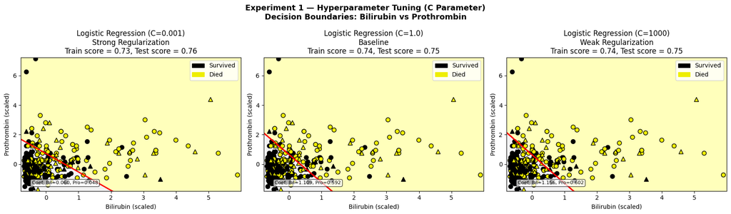

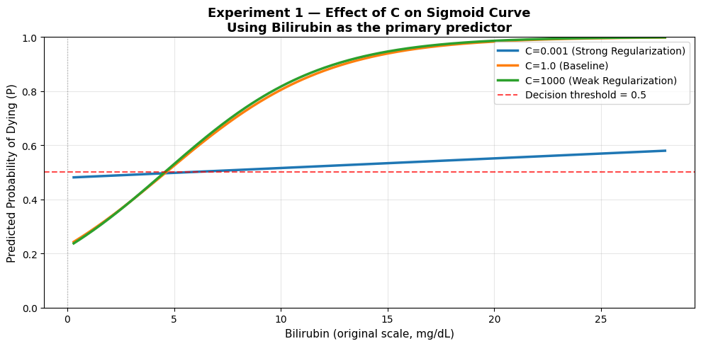

```python
# ============================================================
# CELL 5: EXPERIMENT 1 — HYPERPARAMETER TUNING (C Parameter)
# ============================================================

import numpy as np
import pandas as pd
import matplotlib.pyplot as plt
import matplotlib.patches as mpatches
from matplotlib.colors import ListedColormap
from sklearn.linear_model import LogisticRegression
from sklearn.preprocessing import StandardScaler
from sklearn.metrics import (accuracy_score, precision_score,
                             recall_score, f1_score)

np.set_printoptions(precision=2)

assert 'X_train' in dir(), \
    "X_train not found! Re-run Cell 4 first."
assert len(df) == len(X_train) + len(X_test), \
    "Split mismatch! Re-run Cell 4 first."
print("Sanity check passed — using global split from Cell 4\n")

feat_2d = ['Bilirubin', 'Prothrombin']
target_names = ['Survived', 'Died']

X_train_2d = X_train[feat_2d].values
X_test_2d  = X_test[feat_2d].values

scaler_2d     = StandardScaler()
X_train_2d_sc = scaler_2d.fit_transform(X_train_2d)
X_test_2d_sc  = scaler_2d.transform(X_test_2d)

print(f"Train size : {X_train_2d_sc.shape[0]} samples")
print(f"Test size  : {X_test_2d_sc.shape[0]} samples")
print(f"Features   : {feat_2d}")
print(f"Class dist : Survived={np.bincount(y_test)[0]} | "
      f"Died={np.bincount(y_test)[1]}\n")

C_values   = [0.001, 1.0, 1000]
labels     = ['Strong Regularization', 'Baseline',
               'Weak Regularization']
colors_sig = ['#1f77b4', '#ff7f0e', '#2ca02c']
observations = [
    'Strongest regularization — coefficients shrink '
    'toward zero; sigmoid flattens; tends to underfit.',
    'Baseline — balanced complexity; good trade-off '
    'between bias and variance.',
    'Weakest regularization — coefficients less '
    'constrained; may overfit if test score drops '
    'below training score.',
]
results = []


# ============================================================
# PLOTTING FUNCTION
# (Lecture 5: plot_class_regions_for_classifier_subplot)
# ============================================================

def plot_class_regions_for_classifier_subplot(
        clf, X, y, X_test, y_test, title, subplot,
        target_names=None, plot_decision_regions=True):

    numClasses = np.amax(y) + 1

    color_list_light = ['#EFEFEF', '#FFFFAA']
    color_list_bold  = ['#000000', '#EEEE00']

    cmap_light = ListedColormap(color_list_light[0:numClasses])
    cmap_bold  = ListedColormap(color_list_bold[0:numClasses])

    h = 0.01   # finer mesh for sharper boundary
    k = 1.5    # wider axis padding to show more boundary

    x_plot_adjust  = 0.1
    y_plot_adjust  = 0.1
    plot_symbol_size = 50

    x_min = X[:, 0].min()
    x_max = X[:, 0].max()
    y_min = X[:, 1].min()
    y_max = X[:, 1].max()

    x2, y2 = np.meshgrid(
        np.arange(x_min - k, x_max + k, h),
        np.arange(y_min - k, y_max + k, h))

    P = clf.predict(np.c_[x2.ravel(), y2.ravel()])
    P = P.reshape(x2.shape)

    if plot_decision_regions:
        subplot.contourf(x2, y2, P, cmap=cmap_light, alpha=0.8)
        # Explicit boundary line so it always shows clearly
        subplot.contour(x2, y2, P, levels=[0.5],
                        colors='red', linewidths=2.0,
                        linestyles='-')

    subplot.scatter(X[:, 0], X[:, 1], c=y,
                    cmap=cmap_bold, s=plot_symbol_size,
                    edgecolor='black')
    subplot.set_xlim(x_min - x_plot_adjust, x_max + x_plot_adjust)
    subplot.set_ylim(y_min - y_plot_adjust, y_max + y_plot_adjust)

    if X_test is not None:
        subplot.scatter(X_test[:, 0], X_test[:, 1], c=y_test,
                        cmap=cmap_bold, s=plot_symbol_size,
                        marker='^', edgecolor='black')
        train_score = clf.score(X, y)
        test_score  = clf.score(X_test, y_test)
        title = (title +
                 '\nTrain score = {:.2f}, Test score = {:.2f}'
                 .format(train_score, test_score))

    # Coefficient annotation so change across C is visible
    coef = clf.coef_[0]
    subplot.annotate(
        f'Coef: Bil={coef[0]:.3f}, Pro={coef[1]:.3f}',
        xy=(0.05, 0.05),
        xycoords='axes fraction',
        color='black', fontsize=8,
        bbox=dict(boxstyle='round,pad=0.3',
                  facecolor='white', alpha=0.7))

    subplot.set_title(title)

    if target_names is not None:
        legend_handles = []
        for i in range(len(target_names)):
            patch = mpatches.Patch(
                color=color_list_bold[i],
                label=target_names[i])
            legend_handles.append(patch)
        subplot.legend(loc=0, handles=legend_handles)


# ============================================================
# MODEL IMPLEMENTATION
# ============================================================

fig1, subaxes = plt.subplots(1, 3, figsize=(17, 5))
fig1.suptitle(
    'Experiment 1 — Hyperparameter Tuning (C Parameter)\n'
    'Decision Boundaries: Bilirubin vs Prothrombin',
    fontsize=13, fontweight='bold')

fig2, ax_sig = plt.subplots(figsize=(10, 5))
ax_sig.set_title(
    'Experiment 1 — Effect of C on Sigmoid Curve\n'
    'Using Bilirubin as the primary predictor',
    fontsize=13, fontweight='bold')

bilirubin_range = np.linspace(
    df['Bilirubin'].min(),
    df['Bilirubin'].max(), 300)

for i, (C, label, color, obs) in enumerate(
        zip(C_values, labels, colors_sig, observations)):

    clf = LogisticRegression(
        solver='liblinear', C=C).fit(
        X_train_2d_sc, y_train)

    y_pred = clf.predict(X_test_2d_sc)

    plot_class_regions_for_classifier_subplot(
        clf, X_train_2d_sc, y_train,
        X_test_2d_sc, y_test,
        f'Logistic Regression (C={C})\n{label}',
        subaxes[i],
        target_names=target_names)

    subaxes[i].set_xlabel('Bilirubin (scaled)')
    subaxes[i].set_ylabel('Prothrombin (scaled)')

    bilirubin_scaled = (
        bilirubin_range - scaler_2d.mean_[0]
    ) / scaler_2d.scale_[0]

    z = (clf.coef_[0][0] * bilirubin_scaled
         + clf.intercept_[0])
    sigmoid = 1 / (1 + np.exp(-z))

    ax_sig.plot(bilirubin_range, sigmoid,
                color=color, linewidth=2.5,
                label=f'C={C} ({label})')

    sample_1 = np.array([[2.0, 11.0]])
    sample_2 = np.array([[0.5, 10.2]])
    s1_sc = scaler_2d.transform(sample_1)
    s2_sc = scaler_2d.transform(sample_2)

    print(f'--- C = {C} ({label}) ---')
    print(f'Coefficients : {clf.coef_}')
    print('A patient with Bilirubin=2.0 and Prothrombin=11.0 '
          'is predicted to be: {}'
          .format(target_names[clf.predict(s1_sc)[0]]))
    print('A patient with Bilirubin=0.5 and Prothrombin=10.2 '
          'is predicted to be: {}'
          .format(target_names[clf.predict(s2_sc)[0]]))
    print('Accuracy of Logistic Regression classifier '
          'on training set: {:.2f}'
          .format(clf.score(X_train_2d_sc, y_train)))
    print('Accuracy of Logistic Regression classifier '
          'on test set: {:.2f}'
          .format(clf.score(X_test_2d_sc, y_test)))
    print()

    results.append({
        'C Value'     : C,
        'Label'       : label,
        'Accuracy'    : round(accuracy_score(
                              y_test, y_pred), 4),
        'Precision'   : round(precision_score(
                              y_test, y_pred,
                              zero_division=0), 4),
        'Recall'      : round(recall_score(
                              y_test, y_pred,
                              zero_division=0), 4),
        'F1 Score'    : round(f1_score(
                              y_test, y_pred,
                              zero_division=0), 4),
        'Observation' : obs,
    })

fig1.tight_layout()
fig1.savefig('exp1_decision_boundaries.png',
             dpi=150, bbox_inches='tight')
fig1.show()

ax_sig.axhline(y=0.5, color='red', linestyle='--',
               linewidth=1.5, alpha=0.7,
               label='Decision threshold = 0.5')
ax_sig.axvline(x=0.0, color='gray', linestyle=':',
               linewidth=1, alpha=0.5)
ax_sig.set_xlabel('Bilirubin (original scale, mg/dL)',
                  fontsize=11)
ax_sig.set_ylabel('Predicted Probability of Dying (P)',
                  fontsize=11)
ax_sig.set_ylim(0, 1)
ax_sig.legend(fontsize=10)
ax_sig.grid(True, alpha=0.3)
fig2.tight_layout()
fig2.savefig('exp1_sigmoid_curves.png',
             dpi=150, bbox_inches='tight')
fig2.show()

# ── Monitoring Table ──────────────────────────────────────────
results_df = pd.DataFrame(results)
print('=' * 85)
print('  EXPERIMENT 1 — MONITORING TABLE')
print('=' * 85)
print(results_df[['C Value', 'Label', 'Accuracy',
                   'Precision', 'Recall', 'F1 Score',
                   'Observation']].to_string(index=False))
print('=' * 85)
best = results_df.loc[results_df['F1 Score'].idxmax()]
print(f"\n  Best C = {best['C Value']} ({best['Label']})")
print(f"  Accuracy={best['Accuracy']} | "
      f"Precision={best['Precision']} | "
      f"Recall={best['Recall']} | "
      f"F1={best['F1 Score']}")

# ── C Tuning on Baseline Features ────────────────────────────
baseline_features = ['Bilirubin', 'Albumin', 'Prothrombin']
X_tr_bl = X_train[baseline_features].values
X_te_bl = X_test[baseline_features].values

sc_bl      = StandardScaler()
X_tr_bl_sc = sc_bl.fit_transform(X_tr_bl)
X_te_bl_sc = sc_bl.transform(X_te_bl)

results_bl = []
for C, label, obs in zip(C_values, labels, observations):
    clf_bl = LogisticRegression(
        solver='liblinear', C=C).fit(X_tr_bl_sc, y_train)
    y_pred_bl = clf_bl.predict(X_te_bl_sc)
    results_bl.append({
        'C Value'     : C,
        'Label'       : label,
        'Accuracy'    : round(accuracy_score(
                              y_test, y_pred_bl), 4),
        'Precision'   : round(precision_score(
                              y_test, y_pred_bl,
                              zero_division=0), 4),
        'Recall'      : round(recall_score(
                              y_test, y_pred_bl,
                              zero_division=0), 4),
        'F1 Score'    : round(f1_score(
                              y_test, y_pred_bl,
                              zero_division=0), 4),
        'Observation' : obs,
    })

bl_df = pd.DataFrame(results_bl)
print('=' * 85)
print('  EXPERIMENT 1 — C TUNING ON BASELINE FEATURES')
print('  (Bilirubin, Albumin, Prothrombin)')
print('=' * 85)
print(bl_df[['C Value', 'Label', 'Accuracy',
             'Precision', 'Recall', 'F1 Score',
             'Observation']].to_string(index=False))
print('=' * 85)
best_bl = bl_df.loc[bl_df['F1 Score'].idxmax()]
print(f"\n  Best C on baseline features = {best_bl['C Value']}"
      f" ({best_bl['Label']})")
print(f"  F1={best_bl['F1 Score']} | "
      f"Accuracy={best_bl['Accuracy']} | "
      f"Recall={best_bl['Recall']}")
```

# **Cell 6: Experiment 2 — Feature Engineering and Selection**

### **Purpose**

This experiment investigates how the **number and choice of input features** affects model performance. It runs three model versions — from a single-feature model to an extended 7-feature model — and compares their metrics and confusion matrices. This directly addresses **Lecture 6's guidance on Irrelevant Features** and feature engineering.

The core question is: *Which features carry the most predictive signal for cirrhosis mortality?*

### **Line-by-Line Explanation**

| Line | What it does |
| --- | --- |
| `feature_sets` dictionary | Defines the three models to compare: Model A (1 feature), Model B (3 features), Model C (7 features). Each uses a clinically meaningful combination of cirrhosis biomarkers. |
| `viz_pairs` dictionary | Defines which 2 features to use for the decision boundary plots. Since decision boundaries can only be drawn in 2D, a representative pair is chosen for each model version. |
| **For each model version:** |  |
| `X_tr_f = X_train[features].values` | Subsets only the relevant feature columns from the global training split. |
| `sc_f.fit_transform(X_tr_f)` | Scales only the selected features. A new scaler is created per model version to avoid cross-contamination. |
| `clf_full = LogisticRegression(solver='liblinear', C=1.0)` | Trains a logistic regression model using the full feature set for that model version. Metrics are computed from this full model. |
| `clf_2d = LogisticRegression(...)` | A separate 2D model trained on only 2 features purely for the decision boundary visualization. This is illustrative only — metrics come from the full model. |
| `plot_class_regions_for_classifier_subplot(...)` | Draws the decision boundary for the 2D model (following Lecture 5 structure). |
| Confusion Matrix plots | Shows the 4-cell prediction breakdown (TP, TN, FP, FN) for each model version side-by-side. |
| Monitoring table | Aggregates Accuracy, Precision, Recall, F1-Score for all three models for direct comparison. |

### **Feature Choices and Clinical Justification**

| Model | Features | Rationale |
| --- | --- | --- |
| Model A | Bilirubin only | Bilirubin is the single strongest predictor of liver failure severity. |
| Model B | Bilirubin, Albumin, Prothrombin | The core trio used in clinical scoring systems (e.g., Child-Pugh score). |
| Model C | + Copper, SGOT, Stage, Age | Adds additional lab values and patient characteristics to capture more signal. |

### **Input**

- `X_train`, `X_test`, `y_train`, `y_test` — global split from Cell 4.
- `plot_class_regions_for_classifier_subplot` — plotting function defined in Cell 5.

### **Output**

- Decision boundary plots for all 3 models: `exp2_decision_boundaries.png`
- Confusion matrices for all 3 models: `exp2_confusion.png`
- Monitoring table comparing all 4 metrics across models.
- Best model version identified by highest F1-Score.

```
Sanity check passed — using global split from Cell 4

--- Model A — Single Feature ---
Features for metrics : ['Bilirubin']
A patient with Bilirubin=2.0 and Albumin=3.5 is predicted to be: Survived
A patient with Bilirubin=0.5 and Albumin=4.1 is predicted to be: Survived
Accuracy on training set: 0.70
Accuracy on test set: 0.74

--- Model B — Baseline (3) ---
Features for metrics : ['Bilirubin', 'Albumin', 'Prothrombin']
A patient with Bilirubin=2.0 and Albumin=3.5 is predicted to be: Survived
A patient with Bilirubin=0.5 and Albumin=4.1 is predicted to be: Survived
Accuracy on training set: 0.75
Accuracy on test set: 0.77

--- Model C — Extended (7) ---
Features for metrics : ['Bilirubin', 'Albumin', 'Prothrombin', 'Copper', 'SGOT', 'Stage', 'Age']
A patient with Bilirubin=2.0 and Prothrombin=3.5 is predicted to be: Survived
A patient with Bilirubin=0.5 and Prothrombin=4.1 is predicted to be: Survived
Accuracy on training set: 0.77
Accuracy on test set: 0.86

===========================================================================
  EXPERIMENT 2 — MONITORING TABLE
===========================================================================
                   Model  Accuracy  Precision  Recall  F1 Score
Model A — Single Feature    0.7381     0.7778  0.4375    0.5600
  Model B — Baseline (3)    0.7738     0.8095  0.5312    0.6415
  Model C — Extended (7)    0.8571     0.8571  0.7500    0.8000
===========================================================================

  Best model : Model C — Extended (7)
  F1=0.8 | Accuracy=0.8571 | Recall=0.75
```

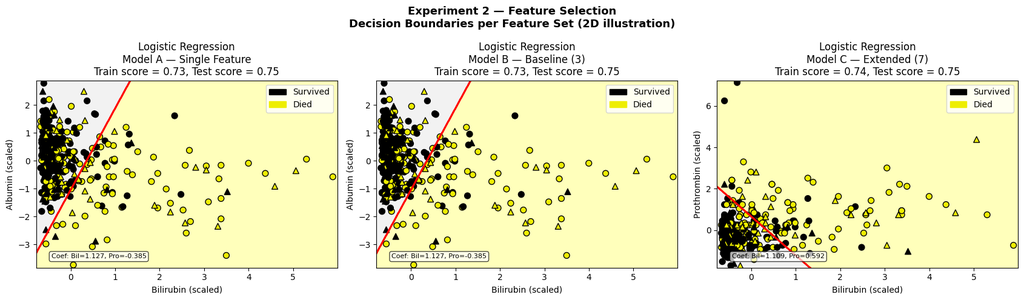

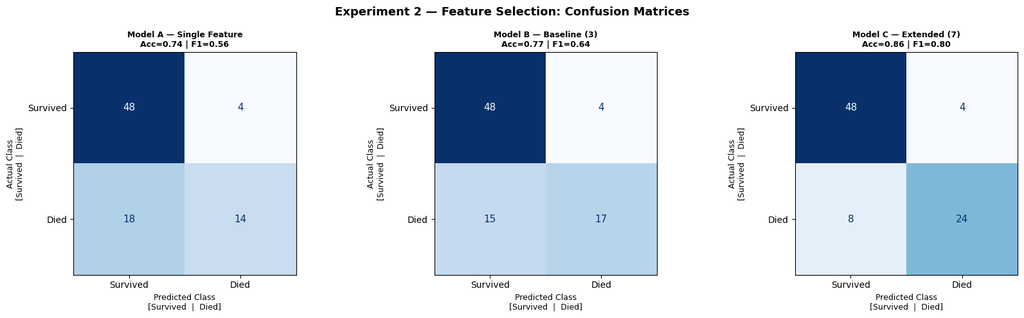

```python
# ============================================================
# CELL 6: EXPERIMENT 2 — FEATURE SELECTION
# ============================================================

import numpy as np
import pandas as pd
import matplotlib.pyplot as plt
import matplotlib.patches as mpatches
from matplotlib.colors import ListedColormap
from sklearn.linear_model import LogisticRegression
from sklearn.preprocessing import StandardScaler
from sklearn.metrics import (accuracy_score, precision_score,
                             recall_score, f1_score,
                             confusion_matrix, ConfusionMatrixDisplay)

np.set_printoptions(precision=2)

assert 'X_train' in dir(), "X_train not found! Re-run Cell 4 first."
assert 'plot_class_regions_for_classifier_subplot' in dir(), "Plotting function not found! Re-run Cell 5 first."
print("Sanity check passed — using global split from Cell 4\n")

target_names_cirrhosis = ['Survived', 'Died']

feature_sets = {
    'Model A — Single Feature' : ['Bilirubin'],
    'Model B — Baseline (3)'   : ['Bilirubin', 'Albumin', 'Prothrombin'],
    'Model C — Extended (7)'   : ['Bilirubin', 'Albumin', 'Prothrombin', 'Copper', 'SGOT', 'Stage', 'Age'],
}

viz_pairs = {
    'Model A — Single Feature' : ['Bilirubin', 'Albumin'],
    'Model B — Baseline (3)'   : ['Bilirubin', 'Albumin'],
    'Model C — Extended (7)'   : ['Bilirubin', 'Prothrombin'],
}

results_feat = []

fig1, subaxes = plt.subplots(1, 3, figsize=(17, 5))
fig1.suptitle('Experiment 2 — Feature Selection\nDecision Boundaries per Feature Set (2D illustration)',
              fontsize=13, fontweight='bold')

for i, (model_name, features) in enumerate(feature_sets.items()):
    X_tr_f = X_train[features].values; X_te_f = X_test[features].values
    sc_f = StandardScaler(); X_tr_f_sc = sc_f.fit_transform(X_tr_f); X_te_f_sc = sc_f.transform(X_te_f)
    clf_full = LogisticRegression(solver='liblinear', C=1.0).fit(X_tr_f_sc, y_train)
    y_pred = clf_full.predict(X_te_f_sc)
    acc  = accuracy_score(y_test, y_pred)
    prec = precision_score(y_test, y_pred, zero_division=0)
    rec  = recall_score(y_test, y_pred, zero_division=0)
    f1   = f1_score(y_test, y_pred, zero_division=0)
    results_feat.append({'Model': model_name, 'Features Used': ', '.join(features),
        'Accuracy': round(acc, 4), 'Precision': round(prec, 4),
        'Recall': round(rec, 4), 'F1 Score': round(f1, 4)})

    viz_cols = viz_pairs[model_name]
    X_tr_2d = X_train[viz_cols].values; X_te_2d = X_test[viz_cols].values
    sc_2d = StandardScaler(); X_tr_2d_sc = sc_2d.fit_transform(X_tr_2d); X_te_2d_sc = sc_2d.transform(X_te_2d)
    clf_2d = LogisticRegression(solver='liblinear', C=1.0).fit(X_tr_2d_sc, y_train)
    plot_class_regions_for_classifier_subplot(
        clf_2d, X_tr_2d_sc, y_train, X_te_2d_sc, y_test,
        f'Logistic Regression\n{model_name}', subaxes[i], target_names=target_names_cirrhosis)
    subaxes[i].set_xlabel(f'{viz_cols[0]} (scaled)')
    subaxes[i].set_ylabel(f'{viz_cols[1]} (scaled)')

    sample_1 = np.array([[2.0, 3.5]]); sample_2 = np.array([[0.5, 4.1]])
    s1_sc = sc_2d.transform(sample_1); s2_sc = sc_2d.transform(sample_2)
    print(f'--- {model_name} ---')
    print(f'Features for metrics : {features}')
    print('A patient with {}={} and {}={} is predicted to be: {}'.format(
        viz_cols[0], sample_1[0][0], viz_cols[1], sample_1[0][1],
        target_names_cirrhosis[clf_2d.predict(s1_sc)[0]]))
    print('A patient with {}={} and {}={} is predicted to be: {}'.format(
        viz_cols[0], sample_2[0][0], viz_cols[1], sample_2[0][1],
        target_names_cirrhosis[clf_2d.predict(s2_sc)[0]]))
    print('Accuracy on training set: {:.2f}'.format(clf_full.score(X_tr_f_sc, y_train)))
    print('Accuracy on test set: {:.2f}'.format(clf_full.score(X_te_f_sc, y_test)))
    print()

fig1.tight_layout()
fig1.savefig('exp2_decision_boundaries.png', dpi=150, bbox_inches='tight')
fig1.show()

fig2, axes2 = plt.subplots(1, 3, figsize=(17, 5))
fig2.suptitle('Experiment 2 — Feature Selection: Confusion Matrices', fontsize=13, fontweight='bold')

for i, (model_name, features) in enumerate(feature_sets.items()):
    X_tr = X_train[features].values; X_te = X_test[features].values
    sc = StandardScaler(); X_tr = sc.fit_transform(X_tr); X_te = sc.transform(X_te)
    clf = LogisticRegression(solver='liblinear', C=1.0).fit(X_tr, y_train)
    y_pred = clf.predict(X_te)
    acc = accuracy_score(y_test, y_pred); f1 = f1_score(y_test, y_pred, zero_division=0)
    ax = axes2[i]
    cm = confusion_matrix(y_test, y_pred)
    disp = ConfusionMatrixDisplay(confusion_matrix=cm, display_labels=target_names_cirrhosis)
    disp.plot(ax=ax, colorbar=False, cmap='Blues')
    ax.set_title(f'{model_name}\nAcc={acc:.2f} | F1={f1:.2f}', fontsize=9, fontweight='bold')
    ax.set_xlabel('Predicted Class\n[Survived  |  Died]', fontsize=9)
    ax.set_ylabel('Actual Class\n[Survived  |  Died]', fontsize=9)
    for text in ax.texts:
        text.set_fontsize(11)

fig2.tight_layout()
fig2.savefig('exp2_confusion.png', dpi=150, bbox_inches='tight')
fig2.show()

feat_df = pd.DataFrame(results_feat)
print('=' * 75)
print('  EXPERIMENT 2 — MONITORING TABLE')
print('=' * 75)
print(feat_df[['Model', 'Accuracy', 'Precision', 'Recall', 'F1 Score']].to_string(index=False))
print('=' * 75)
best_feat = feat_df.loc[feat_df['F1 Score'].idxmax()]
print(f"\n  Best model : {best_feat['Model']}")
print(f"  F1={best_feat['F1 Score']} | Accuracy={best_feat['Accuracy']} | Recall={best_feat['Recall']}")
```

# **Cell 7: Experiment 3 — Decision Threshold Adjustment**

### **Purpose**

This experiment explores how changing the **decision threshold** (the probability cutoff that separates Class 0 and Class 1) affects the trade-off between **False Positives** and **False Negatives**. By default, logistic regression uses a threshold of 0.5, but this may not always be the best choice — especially in medical applications where different error types carry different consequences.

This directly applies **Lecture 6's concept of Ignoring Error Costs**: in a clinical context, a **False Negative** (predicting a dying patient as "Survived") is far more dangerous than a **False Positive** (predicting a surviving patient as "Died").

### **Line-by-Line Explanation**

| Line | What it does |
| --- | --- |
| `best_features = ['Bilirubin', 'Albumin', 'Prothrombin', 'Copper', 'SGOT', 'Stage', 'Age']` | Uses the best-performing feature set identified in Experiment 2 (Model C — 7 features) to ensure we are testing threshold effects on the strongest possible model. |
| `clf_thresh = LogisticRegression(solver='liblinear', C=1.0).fit(...)` | Trains the logistic regression model on the best feature set. |
| `y_proba = clf_thresh.predict_proba(X_te_b_sc)[:, 1]` | Uses `predict_proba()` to get the **raw probability** of class 1 (Died) for each test patient, instead of the hard 0/1 prediction. These probabilities are then thresholded manually. |
| `y_pred_t = (y_proba >= thresh).astype(int)` | Applies the custom threshold: if P(Died) ≥ threshold → predict Died=1, otherwise Survived=0. This is the core technique for threshold adjustment from the exercise instructions. |
| `thresholds = [0.3, 0.5, 0.7]` | Tests three thresholds — lower than default, default, and higher than default. |
| `cm = confusion_matrix(y_test, y_pred_t)` | Computes the confusion matrix for each threshold. |
| `fp = cm[0][1]` | Extracts the **False Positive** count — patients who survived but were predicted to die. |
| `fn = cm[1][0]` | Extracts the **False Negative** count — patients who died but were predicted to survive. This is the **more dangerous error** in this medical context. |
| Precision/Recall/F1 line chart | Shows how all three metrics change as the threshold shifts. As threshold decreases, Recall increases but Precision decreases. |
| FP vs FN bar chart | Directly compares the two error types across thresholds — visually demonstrates the safety trade-off. |

### **What happens when the threshold increases?**

- Higher threshold (e.g., 0.7) → model is more conservative about predicting death → fewer False Positives but **more False Negatives** (more dying patients missed).
- Lower threshold (e.g., 0.3) → model flags more patients as at-risk → more False Positives but **fewer False Negatives** (fewer dying patients missed).

### **Which error is more dangerous in this dataset?**

In a **cirrhosis mortality prediction** context, a **False Negative** is more dangerous. Missing a patient who will die means they may not receive timely treatment, a liver transplant referral, or end-of-life care planning. A False Positive (over-caution) is less harmful — the patient receives additional monitoring but is not harmed by the error.

**Therefore, Threshold = 0.3 is preferred** in this clinical application because it maximizes Recall and minimizes False Negatives, even at the cost of more False Positives.

### **Input**

- `X_train`, `X_test`, `y_train`, `y_test` — global split from Cell 4.
- Best features identified from Experiment 2.

### **Output**

- Confusion matrices for all 3 thresholds: `exp3_confusion.png`
- Precision/Recall/F1 vs Threshold curve and FP vs FN bar chart: `exp3_tradeoff.png`
- Monitoring table with all metrics and error counts per threshold.

```
Sanity check passed — using global split from Cell 4

Train size  : 334 samples
Test size   : 84 samples
Features    : ['Bilirubin', 'Albumin', 'Prothrombin', 'Copper', 'SGOT', 'Stage', 'Age']
Class dist  : Survived=52 | Died=32

--- Threshold = 0.3 ---
Patient 1 (Bilirubin=2.0, Albumin=3.5, Prothrombin=11.0) predicted: Died (P=0.3519)
Patient 2 (Bilirubin=0.5, Albumin=4.1, Prothrombin=10.2) predicted: Survived (P=0.0625)
Accuracy on training set: 0.77
Accuracy on test set: 0.79

--- Threshold = 0.5 ---
Patient 1 (Bilirubin=2.0, Albumin=3.5, Prothrombin=11.0) predicted: Survived (P=0.3519)
Patient 2 (Bilirubin=0.5, Albumin=4.1, Prothrombin=10.2) predicted: Survived (P=0.0625)
Accuracy on training set: 0.77
Accuracy on test set: 0.86

--- Threshold = 0.7 ---
Patient 1 (Bilirubin=2.0, Albumin=3.5, Prothrombin=11.0) predicted: Survived (P=0.3519)
Patient 2 (Bilirubin=0.5, Albumin=4.1, Prothrombin=10.2) predicted: Survived (P=0.0625)
Accuracy on training set: 0.77
Accuracy on test set: 0.80

===========================================================================
  EXPERIMENT 3 — MONITORING TABLE
===========================================================================
 Threshold  Accuracy  Precision  Recall  F1 Score  False Positives  False Negatives
       0.3    0.7857     0.6522  0.9375    0.7692               16                2
       0.5    0.8571     0.8571  0.7500    0.8000                4                8
       0.7    0.7976     0.8947  0.5312    0.6667                2               15
===========================================================================

  Threshold Analysis:
  Threshold=0.3 maximizes Recall (0.9375) and minimizes
  False Negatives (2).
  In this medical context (cirrhosis mortality), missing a dying
  patient (FN) is far more dangerous than a false alarm (FP).
  Therefore, Threshold=0.3 is the preferred clinical threshold.
```

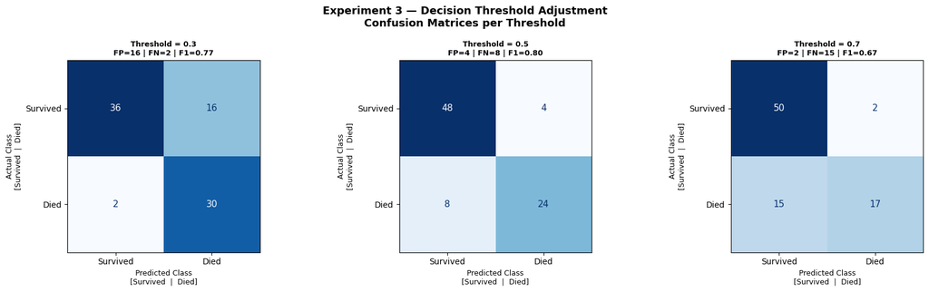

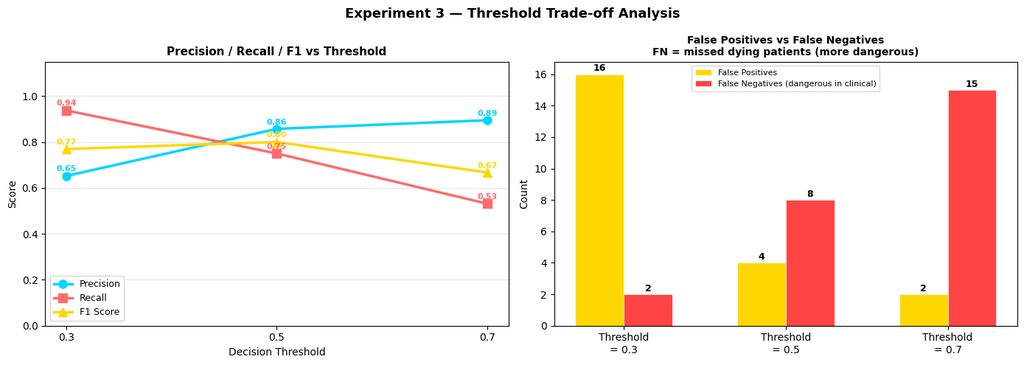

```python
# ============================================================
# CELL 7: EXPERIMENT 3 — DECISION THRESHOLD ADJUSTMENT
# ============================================================

import numpy as np
import pandas as pd
import matplotlib.pyplot as plt
from sklearn.linear_model import LogisticRegression
from sklearn.preprocessing import StandardScaler
from sklearn.metrics import (accuracy_score, precision_score,
                             recall_score, f1_score,
                             confusion_matrix, ConfusionMatrixDisplay)

np.set_printoptions(precision=2)

assert 'X_train' in dir(), "X_train not found! Re-run Cell 4 first."
assert len(df) == len(X_train) + len(X_test), "Split mismatch! Re-run Cell 4 first."
print("Sanity check passed — using global split from Cell 4\n")

best_features     = ['Bilirubin', 'Albumin', 'Prothrombin', 'Copper', 'SGOT', 'Stage', 'Age']
target_names_exp3 = ['Survived', 'Died']

X_tr_b = X_train[best_features].values; X_te_b = X_test[best_features].values
sc_b = StandardScaler(); X_tr_b_sc = sc_b.fit_transform(X_tr_b); X_te_b_sc = sc_b.transform(X_te_b)

clf_thresh = LogisticRegression(solver='liblinear', C=1.0).fit(X_tr_b_sc, y_train)
y_proba = clf_thresh.predict_proba(X_te_b_sc)[:, 1]

print(f"Train size  : {X_tr_b_sc.shape[0]} samples")
print(f"Test size   : {X_te_b_sc.shape[0]} samples")
print(f"Features    : {best_features}")
print(f"Class dist  : Survived={np.bincount(y_test)[0]} | Died={np.bincount(y_test)[1]}\n")

thresholds  = [0.3, 0.5, 0.7]
results_thr = []

fig1, axes1 = plt.subplots(1, 3, figsize=(17, 5))
fig1.suptitle('Experiment 3 — Decision Threshold Adjustment\nConfusion Matrices per Threshold',
              fontsize=13, fontweight='bold')

for i, thresh in enumerate(thresholds):
    y_pred_t = (y_proba >= thresh).astype(int)
    acc  = accuracy_score(y_test, y_pred_t)
    prec = precision_score(y_test, y_pred_t, zero_division=0)
    rec  = recall_score(y_test, y_pred_t, zero_division=0)
    f1   = f1_score(y_test, y_pred_t, zero_division=0)
    cm   = confusion_matrix(y_test, y_pred_t)
    fp   = cm[0][1]; fn = cm[1][0]
    results_thr.append({'Threshold': thresh, 'Accuracy': round(acc, 4),
        'Precision': round(prec, 4), 'Recall': round(rec, 4),
        'F1 Score': round(f1, 4), 'False Positives': fp, 'False Negatives': fn})

    ax = axes1[i]
    disp = ConfusionMatrixDisplay(confusion_matrix=cm, display_labels=target_names_exp3)
    disp.plot(ax=ax, colorbar=False, cmap='Blues')
    ax.set_title(f'Threshold = {thresh}\nFP={fp} | FN={fn} | F1={f1:.2f}', fontsize=9, fontweight='bold')
    ax.set_xlabel('Predicted Class\n[Survived  |  Died]', fontsize=9)
    ax.set_ylabel('Actual Class\n[Survived  |  Died]', fontsize=9)
    for text in ax.texts:
        text.set_fontsize(11)

    sample_1 = sc_b.transform([[2.0, 3.5, 11.0, 80.0, 90.0, 3.0, 55.0]])
    sample_2 = sc_b.transform([[0.5, 4.1, 10.2, 40.0, 60.0, 2.0, 45.0]])
    p1 = clf_thresh.predict_proba(sample_1)[0][1]
    p2 = clf_thresh.predict_proba(sample_2)[0][1]
    print(f'--- Threshold = {thresh} ---')
    print('Patient 1 (Bilirubin=2.0, Albumin=3.5, Prothrombin=11.0) predicted: {} (P={:.4f})'.format(
        target_names_exp3[int(p1 >= thresh)], p1))
    print('Patient 2 (Bilirubin=0.5, Albumin=4.1, Prothrombin=10.2) predicted: {} (P={:.4f})'.format(
        target_names_exp3[int(p2 >= thresh)], p2))
    print('Accuracy on training set: {:.2f}'.format(clf_thresh.score(X_tr_b_sc, y_train)))
    print('Accuracy on test set: {:.2f}'.format(acc)); print()

fig1.tight_layout()
fig1.savefig('exp3_confusion.png', dpi=150, bbox_inches='tight')
fig1.show()

fig2, axes2 = plt.subplots(1, 2, figsize=(14, 5))
fig2.suptitle('Experiment 3 — Threshold Trade-off Analysis', fontsize=13, fontweight='bold')

ax_l = axes2[0]
prec_vals = [r['Precision'] for r in results_thr]
rec_vals  = [r['Recall'] for r in results_thr]
f1_vals   = [r['F1 Score'] for r in results_thr]
ax_l.plot(thresholds, prec_vals, 'o-', color='#00d4ff', linewidth=2.5, markersize=8, label='Precision')
ax_l.plot(thresholds, rec_vals,  's-', color='#ff6b6b', linewidth=2.5, markersize=8, label='Recall')
ax_l.plot(thresholds, f1_vals,   '^-', color='#ffd700', linewidth=2.5, markersize=8, label='F1 Score')
for j, t in enumerate(thresholds):
    for vals, color in [(prec_vals,'#00d4ff'),(rec_vals,'#ff6b6b'),(f1_vals,'#ffd700')]:
        ax_l.text(t, vals[j]+0.02, f'{vals[j]:.2f}', ha='center', color=color, fontsize=8, fontweight='bold')
ax_l.set_ylim(0, 1.15); ax_l.set_xticks(thresholds)
ax_l.set_title('Precision / Recall / F1 vs Threshold', fontsize=11, fontweight='bold')
ax_l.set_xlabel('Decision Threshold', fontsize=10); ax_l.set_ylabel('Score', fontsize=10)
ax_l.legend(fontsize=9); ax_l.grid(axis='y', alpha=0.3)

ax_r = axes2[1]
x = np.arange(len(thresholds)); width = 0.3
fp_vals = [r['False Positives'] for r in results_thr]
fn_vals = [r['False Negatives'] for r in results_thr]
b1 = ax_r.bar(x - width/2, fp_vals, width, label='False Positives', color='#ffd700', edgecolor='white', linewidth=0.5)
b2 = ax_r.bar(x + width/2, fn_vals, width, label='False Negatives (dangerous in clinical)', color='#ff4444', edgecolor='white', linewidth=0.5)
for bar, v in zip(list(b1)+list(b2), fp_vals+fn_vals):
    ax_r.text(bar.get_x()+bar.get_width()/2, bar.get_height()+0.2, str(v), ha='center', fontsize=9, fontweight='bold')
ax_r.set_xticks(x); ax_r.set_xticklabels([f'Threshold\n= {t}' for t in thresholds])
ax_r.set_title('False Positives vs False Negatives\nFN = missed dying patients (more dangerous)', fontsize=10, fontweight='bold')
ax_r.set_ylabel('Count', fontsize=10); ax_r.legend(fontsize=8)

fig2.tight_layout()
fig2.savefig('exp3_tradeoff.png', dpi=150, bbox_inches='tight')
fig2.show()

thr_df = pd.DataFrame(results_thr)
print('=' * 75)
print('  EXPERIMENT 3 — MONITORING TABLE')
print('=' * 75)
print(thr_df.to_string(index=False))
print('=' * 75)
print(f"\n  Threshold Analysis:")
print(f"  Threshold=0.3 maximizes Recall ({thr_df.loc[0,'Recall']}) and minimizes")
print(f"  False Negatives ({thr_df.loc[0,'False Negatives']}).")
print(f"  In this medical context (cirrhosis mortality), missing a dying")
print(f"  patient (FN) is far more dangerous than a false alarm (FP).")
print(f"  Therefore, Threshold=0.3 is the preferred clinical threshold.")
```

# **Cell 8: Multinomial Logistic Regression — 10-Fold Cross-Validation**

### **Purpose**

This cell extends the analysis beyond binary classification to **Multinomial Logistic Regression** using the original 3-class target (Alive, Died, Liver Transplant). It implements **10-Fold Cross-Validation** to provide a more robust and unbiased evaluation of model performance directly following the **Lecture 6 code structure** for multinomial logistic regression with K-Fold CV.

### **Why 10-Fold instead of the 5-Fold in Lecture 6?**

The Cirrhosis dataset has only 418 samples, with the transplant class (CL) containing only ~25 patients. With 5-fold CV, each test fold would have only ~5 CL samples — too few for reliable evaluation. 10-fold preserves more training data per fold (90% vs 80%), which is critical for the minority class. Lecture 6 itself states: *"the choice of the number of folds depends on the size of the dataset."*

### **Why is `multi_class='multinomial'` not included?**

The `multi_class` parameter was deprecated in scikit-learn 1.5 and will be removed in 1.7. When using `solver='lbfgs'` with a target that has more than 2 classes, scikit-learn automatically applies multinomial logistic regression. The behavior is identical — the parameter is simply no longer required.

### **Line-by-Line Explanation**

| Line | What it does |
| --- | --- |
| `df_multi = df_raw.copy()` | Creates a fresh copy of the raw data to apply cleaning while **preserving the original 3-class Status** (C, D, CL) instead of collapsing to binary. |
| `le = LabelEncoder()` | Creates a LabelEncoder that converts string class labels to integers: C→0, CL→1, D→2. |
| `df_multi['Status'] = le.fit_transform(df_multi['Status'])` | Encodes the 3-class target. `le.classes_` stores the original label names for use in the confusion matrix. |
| Cleaning steps (replace NA, drop duplicates, fill missing, encode) | Repeats the same cleaning logic from Cell 3, but on `df_multi` and keeping the 3-class target. |
| `feature_cols = ['Bilirubin', 'Albumin', 'Prothrombin', 'Copper', 'SGOT', 'Stage', 'Age']` | Uses the best 7-feature set from Experiment 2 for consistency. |
| `X_multi = df_multi[feature_cols].values` | Extracts the feature matrix as a NumPy array. |
| `y_multi = df_multi['Status'].values` | Extracts the 3-class target vector. |
| `scaler_multi = StandardScaler()` | Creates the scaler. Note: fitted on the full dataset here because K-Fold CV handles the train/test split internally. |
| `X_multi_sc = scaler_multi.fit_transform(X_multi)` | Scales all features to mean=0 and std=1. |
| `model_multi = LogisticRegression(solver='lbfgs', max_iter=1000, random_state=42)` | Defines the multinomial logistic regression model. `lbfgs` is the standard solver for multi-class problems. `max_iter=1000` ensures convergence. |
| `kf = KFold(n_splits=10, shuffle=True, random_state=42)` | Creates the 10-fold cross-validation splitter. `shuffle=True` randomizes fold assignment before splitting. `random_state=42` ensures reproducibility. |
| `scores = cross_val_score(model_multi, X_multi_sc, y_multi, cv=kf, scoring='accuracy')` | Runs 10 complete train/test cycles, each time training on 9 folds and testing on the remaining 1 fold. Returns an array of 10 accuracy scores. |
| `scores.mean()` | The **overall mean accuracy** across all 10 folds — this is the primary cross-validation performance metric. |
| `scores.std()` | The standard deviation of fold scores — measures stability. A low std means the model performs consistently across all data splits. |
| Fold accuracy line chart | Plots each fold's accuracy as a point connected by a line (Lecture 6 visualization style). The red dashed line marks the mean accuracy. |
| Confusion matrix (full refit) | Refits the model on the entire dataset and shows the per-class prediction breakdown. This is illustrative — the CV scores are the proper performance measure. |
| `classification_report(...)` | Prints per-class Precision, Recall, and F1-Score for all 3 classes (Alive, Transplant, Died). |

### **Input**

- `df_raw` — the original unmodified dataset from Cell 1.
- `df` — the cleaned dataset from Cell 3 (used for sanity check only).

### **Output**

- 10-fold cross-validation accuracy scores (array of 10 values).
- Mean accuracy, standard deviation, min, and max fold scores.
- Line chart of fold accuracies with mean line: `cell8_multinomial_cv.png`
- Confusion matrix for the 3-class multinomial model.
- Per-class classification report.
- 10-fold CV summary table.

```
Sanity check passed — df_raw and df are available

[OK] 3-class target encoded:
     Class 0 (C): 232 samples
     Class 1 (CL): 25 samples
     Class 2 (D): 161 samples

[OK] Multinomial dataset ready
     Shape  : 418 rows × 19 columns
     Missing: 0

[OK] Features : ['Bilirubin', 'Albumin', 'Prothrombin', 'Copper', 'SGOT', 'Stage', 'Age']
     X shape  : (418, 7)
     y shape  : (418,)

[OK] Features standardized (StandardScaler)

=======================================================
  MULTINOMIAL LOGISTIC REGRESSION — 10-FOLD CV
=======================================================
  Classes       : ['C', 'CL', 'D']
  Features used : 7
  Total samples : 418
=======================================================

Accuracy Score per Fold: [0.76 0.74 0.69 0.76 0.69 0.67 0.81 0.74 0.61 0.78]
Overall Mean Accuracy  : 0.7247
Standard Deviation     : 0.0569
Min Fold Accuracy      : 0.6098
Max Fold Accuracy      : 0.8095
```

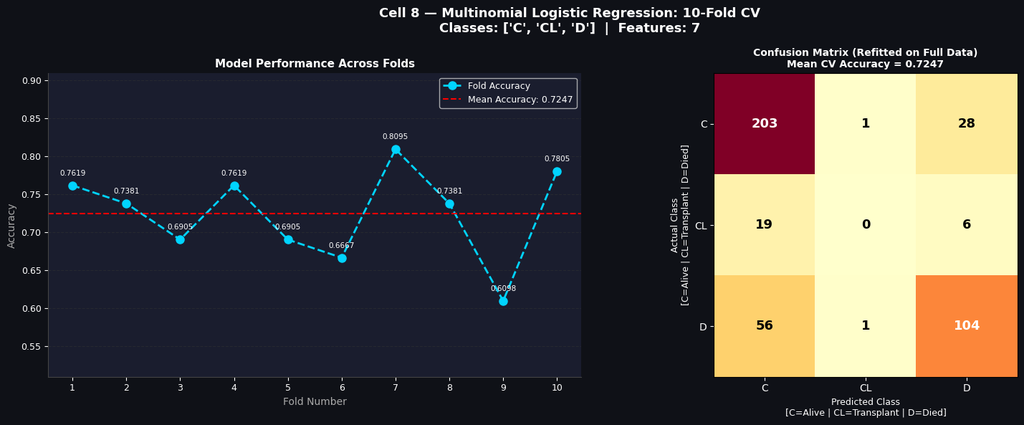

```
=======================================================
  PER-CLASS CLASSIFICATION REPORT
  (Model refitted on full dataset — illustrative)
=======================================================
              precision    recall  f1-score   support

           C       0.73      0.88      0.80       232
          CL       0.00      0.00      0.00        25
           D       0.75      0.65      0.70       161

    accuracy                           0.73       418
   macro avg       0.49      0.51      0.50       418
weighted avg       0.70      0.73      0.71       418


=======================================================
  10-FOLD CV SUMMARY TABLE
=======================================================
   Fold  Accuracy
      1    0.7619
      2    0.7381
      3    0.6905
      4    0.7619
      5    0.6905
      6    0.6667
      7    0.8095
      8    0.7381
      9    0.6098
     10    0.7805
   Mean    0.7247
Std Dev    0.0569
=======================================================
```

```python
# ============================================================
# CELL 8: MULTINOMIAL LOGISTIC REGRESSION — 10-FOLD CV
# ============================================================

import numpy as np
import pandas as pd
import matplotlib.pyplot as plt
from sklearn.linear_model import LogisticRegression
from sklearn.model_selection import KFold, cross_val_score
from sklearn.preprocessing import StandardScaler, LabelEncoder
from sklearn.metrics import (accuracy_score, confusion_matrix,
                             ConfusionMatrixDisplay, classification_report)

np.set_printoptions(precision=2)

assert 'df_raw' in dir(), "df_raw not found! Re-run Cell 1 first."
assert 'df' in dir(), "df not found! Re-run Cell 3 first."
print("Sanity check passed — df_raw and df are available\n")

# ── Reconstruct 3-Class Target from df_raw ───────────────────
df_multi = df_raw.copy()
df_multi.replace("NA", np.nan, inplace=True)
df_multi['Stage'] = pd.to_numeric(df_multi['Stage'], errors='coerce')
df_multi.drop(columns=['ID'], inplace=True)
df_multi.drop_duplicates(inplace=True)

le = LabelEncoder()
df_multi['Status'] = le.fit_transform(df_multi['Status'])
class_names = list(le.classes_)
print(f"[OK] 3-class target encoded:")
for i, cls in enumerate(class_names):
    count = (df_multi['Status'] == i).sum()
    print(f"     Class {i} ({cls}): {count} samples")

for col in ['Drug', 'Ascites', 'Hepatomegaly', 'Spiders']:
    df_multi[col] = df_multi[col].fillna(df_multi[col].mode()[0])
for col in ['Cholesterol', 'Copper', 'Alk_Phos', 'SGOT', 'Tryglicerides', 'Platelets', 'Prothrombin']:
    df_multi[col] = df_multi[col].fillna(df_multi[col].median())
df_multi['Stage'] = df_multi['Stage'].fillna(df_multi['Stage'].mode()[0])

df_multi['Sex']  = (df_multi['Sex']  == 'M').astype(int)
df_multi['Drug'] = (df_multi['Drug'] == 'D-penicillamine').astype(int)
for col in ['Ascites', 'Hepatomegaly', 'Spiders']:
    df_multi[col] = (df_multi[col] == 'Y').astype(int)
df_multi['Edema'] = df_multi['Edema'].map({'N': 0, 'S': 0.5, 'Y': 1})
df_multi['Age'] = (df_multi['Age'] / 365.25).round(1)

print(f"\n[OK] Multinomial dataset ready")
print(f"     Shape  : {df_multi.shape[0]} rows × {df_multi.shape[1]} columns")
print(f"     Missing: {df_multi.isnull().sum().sum()}")

feature_cols = ['Bilirubin', 'Albumin', 'Prothrombin', 'Copper', 'SGOT', 'Stage', 'Age']
X_multi = df_multi[feature_cols].values
y_multi = df_multi['Status'].values

print(f"\n[OK] Features : {feature_cols}")
print(f"     X shape  : {X_multi.shape}")
print(f"     y shape  : {y_multi.shape}")

scaler_multi = StandardScaler()
X_multi_sc   = scaler_multi.fit_transform(X_multi)
print(f"\n[OK] Features standardized (StandardScaler)")

model_multi = LogisticRegression(solver='lbfgs', max_iter=1000, random_state=42)
kf = KFold(n_splits=10, shuffle=True, random_state=42)
scores = cross_val_score(model_multi, X_multi_sc, y_multi, cv=kf, scoring='accuracy')

print("\n" + "=" * 55)
print("  MULTINOMIAL LOGISTIC REGRESSION — 10-FOLD CV")
print("=" * 55)
print(f"  Classes       : {class_names}")
print(f"  Features used : {len(feature_cols)}")
print(f"  Total samples : {len(y_multi)}")
print("=" * 55)
print(f"\nAccuracy Score per Fold: {np.round(scores, 4)}")
print(f"Overall Mean Accuracy  : {scores.mean():.4f}")
print(f"Standard Deviation     : {scores.std():.4f}")
print(f"Min Fold Accuracy      : {scores.min():.4f}")
print(f"Max Fold Accuracy      : {scores.max():.4f}")

fig, axes = plt.subplots(1, 2, figsize=(16, 6))
fig.patch.set_facecolor('#0f1117')
fig.suptitle(f'Cell 8 — Multinomial Logistic Regression: 10-Fold CV\nClasses: {class_names}  |  Features: {len(feature_cols)}',
             color='white', fontsize=13, fontweight='bold')

ax1 = axes[0]
ax1.set_facecolor('#1a1d2e')
ax1.plot(range(1, len(scores)+1), scores, marker='o', linestyle='--',
         color='#00d4ff', linewidth=2, markersize=8, label='Fold Accuracy')
ax1.axhline(y=scores.mean(), color='red', linestyle='--', linewidth=1.5,
            label=f'Mean Accuracy: {scores.mean():.4f}')
for fold, score in enumerate(scores, 1):
    ax1.annotate(f'{score:.4f}', xy=(fold, score), xytext=(0, 10),
                 textcoords='offset points', ha='center', color='white', fontsize=7.5)
ax1.set_title('Model Performance Across Folds', color='white', fontweight='bold', fontsize=11)
ax1.set_xlabel('Fold Number', color='#aaaaaa', fontsize=10)
ax1.set_ylabel('Accuracy', color='#aaaaaa', fontsize=10)
ax1.set_xticks(range(1, len(scores)+1))
ax1.set_ylim(max(0, scores.min()-0.1), min(1.0, scores.max()+0.1))
ax1.tick_params(colors='white', labelsize=9)
ax1.spines[['top','right']].set_visible(False)
ax1.spines[['left','bottom']].set_color('#444444')
ax1.legend(facecolor='#1a1d2e', labelcolor='white', fontsize=9)
ax1.grid(axis='y', color='#333333', linestyle='--', alpha=0.5)

ax2 = axes[1]
ax2.set_facecolor('#1a1d2e')
model_multi.fit(X_multi_sc, y_multi)
y_pred_multi = model_multi.predict(X_multi_sc)
cm_multi = confusion_matrix(y_multi, y_pred_multi)
disp = ConfusionMatrixDisplay(confusion_matrix=cm_multi, display_labels=class_names)
disp.plot(ax=ax2, colorbar=False, cmap='YlOrRd')
ax2.set_title(f'Confusion Matrix (Refitted on Full Data)\nMean CV Accuracy = {scores.mean():.4f}',
              color='white', fontweight='bold', fontsize=10)
ax2.set_xlabel('Predicted Class\n[C=Alive | CL=Transplant | D=Died]', color='white', fontsize=9)
ax2.set_ylabel('Actual Class\n[C=Alive | CL=Transplant | D=Died]', color='white', fontsize=9)
ax2.tick_params(colors='white')
threshold = cm_multi.max() / 2
for text in ax2.texts:
    val = float(text.get_text())
    text.set_color('white' if val > threshold else 'black')
    text.set_fontsize(13); text.set_fontweight('bold')
ax2.set_facecolor('#1a1d2e')

plt.tight_layout()
plt.savefig('cell8_multinomial_cv.png', dpi=150, bbox_inches='tight', facecolor='#0f1117')
plt.show()

print("\n" + "=" * 55)
print("  PER-CLASS CLASSIFICATION REPORT")
print("  (Model refitted on full dataset — illustrative)")
print("=" * 55)
print(classification_report(y_multi, y_pred_multi, target_names=class_names))

summary_rows = [{'Fold': i+1, 'Accuracy': round(s, 4)} for i, s in enumerate(scores)]
summary_rows.append({'Fold': 'Mean',    'Accuracy': round(scores.mean(), 4)})
summary_rows.append({'Fold': 'Std Dev', 'Accuracy': round(scores.std(),  4)})
summary_df = pd.DataFrame(summary_rows)
print("\n" + "=" * 55)
print("  10-FOLD CV SUMMARY TABLE")
print("=" * 55)
print(summary_df.to_string(index=False))
print("=" * 55)
```